# Kernel Density Estimation

Josie Wood

April 30, 2018

### Introduction

Every random variable has a density. Densities provide valuable information about the variable, and the distribution of data. However, these densities are not always explictly known. Often, in the interest of prediction, assumptions are made about the distribution and density of data. When the distribution and density are known, or assumed, parametric techniques can be employed. Otherwise, non-parametric statistical methods are used to estimate the density of data. One such method is Kernel Density Estimation (KDE).

To illustrate this technique, consider a random variable $X$ with unknown density $f_X$. KDE begins by taking a weighted average of several data values near a point $x$ in order to estimate $f_X(x)$. We define some function $k(z)$ to be a symmetric probability density function, with mean 0. This may be, for example, $Z\sim N(0,1)$. Also define $\Delta$ as the *bandwidth*. We then find the kernel density estimate to be:

$\displaystyle \hat f(x)=\frac{1}{n\Delta}\sum^{n}_{i=1}w(\frac{x-X_i}{\Delta})$

Here, the bandwidth choice is incredibly important. Smaller bandwidth, $\Delta$, values will result in a more rigid density fit. Larger values result in a smoother estimate. For example, consider using a normal kernel with $\Delta_1 = .2$ and $\Delta_2 = .8$ to estimate a normal random variable.

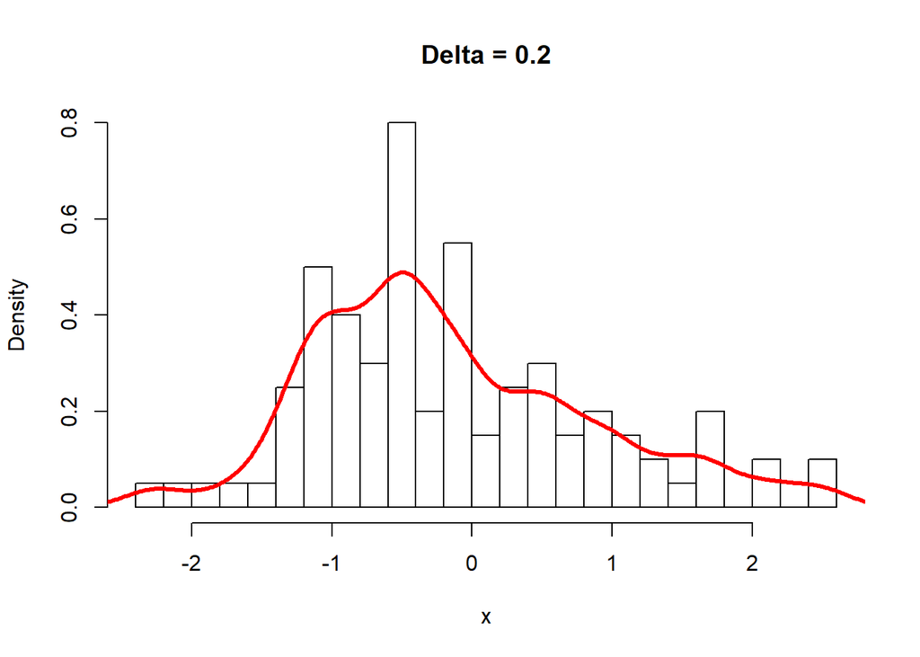

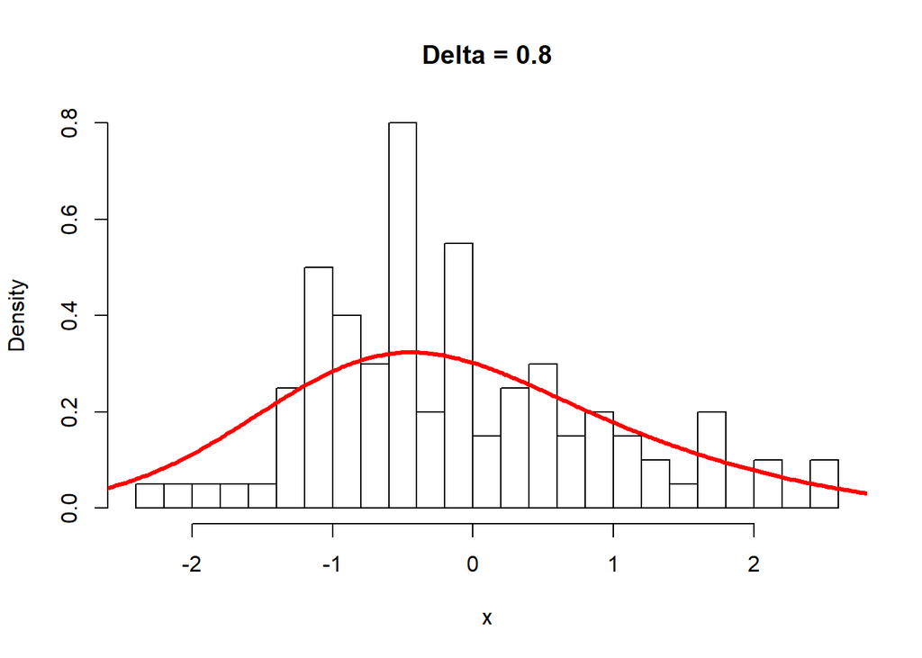

There are a few methods for choosing a $\Delta$, such as Mean Integrated Squared Error. Here the focus will be on the Standard Deviation and Scaled Interquartile Range formulas suggested by Hardle (1991). These formulas are as follows:

$$\begin{aligned}
\Delta &= \frac{1.06}{n^{\frac{1}{5}}} S \\
\Delta &= \frac{1.06}{n^{\frac{1}{5}}}\times\frac{IQR}{1.34}
\end{aligned}$$
The second formula for choosing $\Delta$ helps to control for the influence of outliers in the data. But does that mean that it performs better overall? What is the optimal choice of bandwidth?

To answer this question, both bandwidth formulas are compared in the context of estimating the density of three different distributions.

First, we again consider estimating a normal density by simulating 100 random variables $X_1,X_2,...,X_{100}$ iid $N(0,1)$. The two bandwidth methods are then used to estimate densities for each $X_i$.

This results in 100 simulated kernel density estimates that are then plotted against true normal density function for comparison. While interesting, this visual comparison is not enough to determine which bandwidth results in a better estimate. Instead, we are interested in finding the mean distance from the true density for each bandwidth method. To do this, we calculate the mean area between the simulated kernel densities and the true density. This is calculated by taking the area under the simulated curve (AUC) and subtracting 1, as the AUC of any density function is 1.

This process is then repeated for estimating Gamma and Weibull random variables, with varied results.

Below, the simulated densities for the each density are shown with the true density drawn in black.

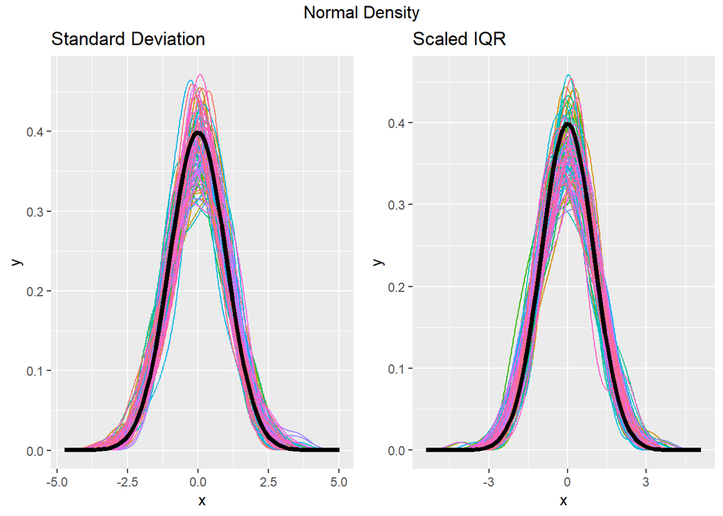

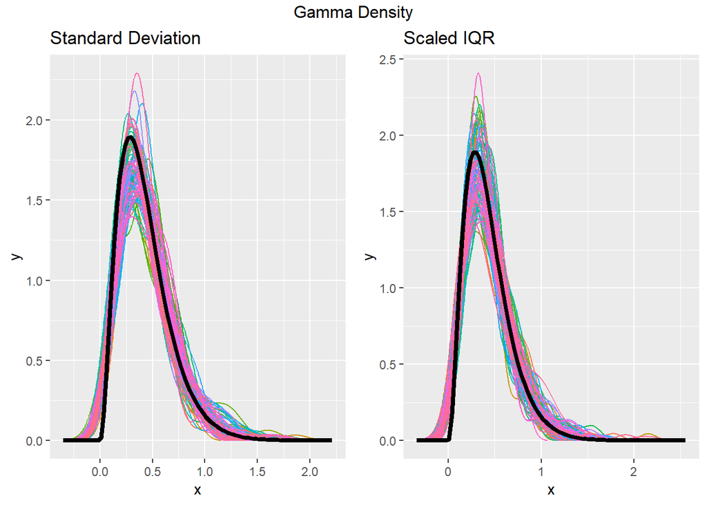

Again, we see that the Scaled IQR varies more than the Standard Deviation KDE.

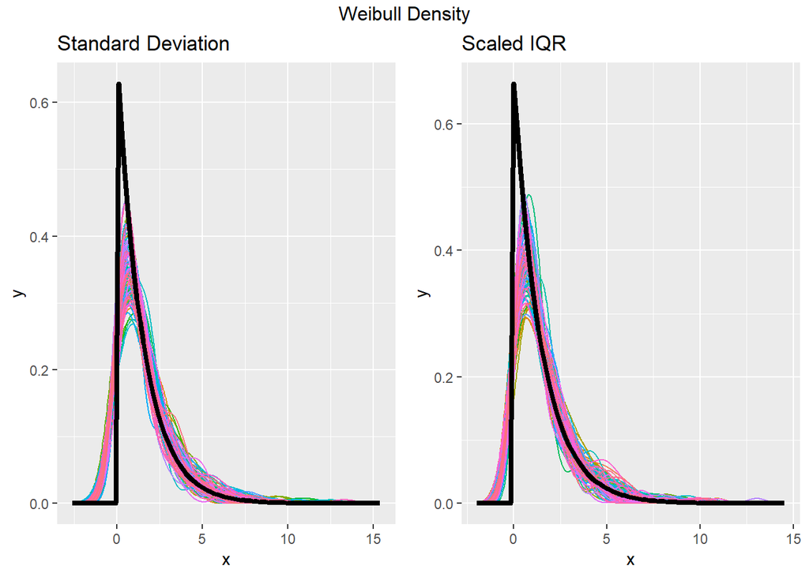

For the Weibull density, above, we see that neither bandwidth formula performed well. While the general shape is accurate, both KDE comes up short compared to the true density.

Now, if we look at the mean area between the curves:

[output not shown]

So then we can see that for each distribution, the Standard Deviation bandwidth choice was closer to the true density than the Scaled IQR, even if just by a little bit. Interestingly, we see that the KDE for the Weibull were closer than the other distributions, though they looked further visually.

By simulating random variables from Normal, Gamma, and Weibull distributions, we attempted to estimate these densities using the non-parametric method of Kernel Density Estimation. To do this sort of density estimation, a bandwidth value must be chosen. Multiple selection techniques have been suggested, and we compared two standard methods, Hardle’s Standard Deviation and Scaled IQR formulas.

The results were a bit surprising; I expected the Scaled IQR method to be more robust as it is not as influenced by outliers. However, this is an interesting follow up question. How much better is the Scaled IQR method when outliers have been introduced into the data? There are also other methods for bandwidth choice available. It would be interesting to explore more data dependent methods such as Mean Integrated Square Error. Along that line, in this study we used the same bandwidth selection method for three different distribution estimations. While they performed similarly across all three, how can the bandwidth be optimized for a specific distribution?

#### Appendix

```r
set.seed(1234)
n <- 100
x <- rnorm(n,0,1)
a <- seq(min(x),max(x),0.01)
```

```r
# Delta with Standard Deviation

library(ggplot2)

#p <- p + aes(qnorm(a)) + geom_histogram(binwidth=.5, colour="black", fill="white")

df.sd <- NULL

for (i in 1:100){
  x <- rnorm(n,0,1)
  band <- sd(x)*1.06/(n^(1/5))
  dens <- density(x,bw=band)
  temp <- data.frame(x=dens$x,y=dens$y,col=rep(i))
  df.sd <- rbind(df.sd,temp)
}

sdp.norm <- ggplot(df.sd,aes(x=x,y=y,group=col,colour=factor(col))) + geom_line() + stat_function(fun = dnorm, colour = "black", size = 1.5) + ggtitle("Standard Deviation") + theme(legend.position="none")
```

```r
# Delta with Scaled IQR
library(ggplot2)

#p <- p + aes(qnorm(a)) + geom_histogram(binwidth=.5, colour="black", fill="white")

df.iqr <- NULL

for (i in 1:100){
  x <- rnorm(n,0,1)
  band <- (IQR(x)/1.34)*1.06/(n^(1/5))
  dens <- density(x,bw=band)
  temp <- data.frame(x=dens$x,y=dens$y,col=rep(i))
  df.iqr <- rbind(df.iqr,temp)
}

iqrp.norm <- ggplot(df.iqr,aes(x=x,y=y,group=col,colour=factor(col))) + geom_line() + stat_function(fun = dnorm, colour = "black", size = 1.5) + ggtitle("Scaled IQR") + theme(legend.position="none")
```

```r
library(zoo)

iqr.auc.norm <- list()

for (i in 1:100){
  x <- df.iqr[df.iqr$col == i,]$x
  y <- df.iqr[df.iqr$col == i,]$y
  id <- order(x)
  iqr.auc.norm[i] <- sum(diff(x[id])*rollmean(y[id],2)) - 1
}

sd.auc.norm <- list()

for (i in 1:100){
  x <- df.sd[df.sd$col == i,]$x
  y <- df.sd[df.sd$col == i,]$y
  id <- order(x)
  sd.auc.norm[i] <- sum(diff(x[id])*rollmean(y[id],2)) - 1
}
```

```r
# Delta with Standard Deviation

library(ggplot2)

#p <- p + aes(qnorm(a)) + geom_histogram(binwidth=.5, colour="black", fill="white")

df.sd <- NULL

for (i in 1:100){
  x <- rgamma(n,3,7)
  band <- sd(x)*1.06/(n^(1/5))
  dens <- density(x,bw=band)
  temp <- data.frame(x=dens$x,y=dens$y,col=rep(i))
  df.sd <- rbind(df.sd,temp)
}

sdp.gamma <- ggplot(df.sd,aes(x=x,y=y,group=col,colour=factor(col))) + geom_line() + stat_function(fun = dgamma, args=list(shape=3,rate=7), colour = "black",size=1.5) + ggtitle("Standard Deviation") + theme(legend.position="none")
```

```r
# Delta with Scaled IQR
library(ggplot2)

#p <- p + aes(qnorm(a)) + geom_histogram(binwidth=.5, colour="black", fill="white")

df.iqr <- NULL

for (i in 1:100){
  x <- rgamma(n,3,7)
  band <- (IQR(x)/1.34)*1.06/(n^(1/5))
  dens <- density(x,bw=band)
  temp <- data.frame(x=dens$x,y=dens$y,col=rep(i))
  df.iqr <- rbind(df.iqr,temp)
}

iqrp.gamma <- ggplot(df.iqr,aes(x=x,y=y,group=col,colour=factor(col))) + geom_line() + stat_function(fun = dgamma, args=list(shape=3,rate=7), colour = "black",size=1.5) + ggtitle("Scaled IQR") + theme(legend.position="none")
```

```r
library(zoo)

iqr.auc.gamma <- list()

for (i in 1:100){
  x <- df.iqr[df.iqr$col == i,]$x
  y <- df.iqr[df.iqr$col == i,]$y
  id <- order(x)
  iqr.auc.gamma[i] <- sum(diff(x[id])*rollmean(y[id],2)) - 1
}

sd.auc.gamma <- list()

for (i in 1:100){
  x <- df.sd[df.sd$col == i,]$x
  y <- df.sd[df.sd$col == i,]$y
  id <- order(x)
  sd.auc.gamma[i] <- sum(diff(x[id])*rollmean(y[id],2)) - 1
}
```

```r
# Delta with Standard Deviation

library(ggplot2)

#p <- p + aes(qnorm(a)) + geom_histogram(binwidth=.5, colour="black", fill="white")

df.sd <- NULL

for (i in 1:100){
  x <- rweibull(n,1,1.5)
  band <- sd(x)*1.06/(n^(1/5))
  dens <- density(x,bw=band)
  temp <- data.frame(x=dens$x,y=dens$y,col=rep(i))
  df.sd <- rbind(df.sd,temp)
}

sdp.weibull <- ggplot(df.sd,aes(x=x,y=y,group=col,colour=factor(col))) + geom_line() + stat_function(fun = dweibull, args=list(shape=1,scale=1.5), colour = "black",size=1.5) + ggtitle("Standard Deviation") + theme(legend.position="none")
```

```r
# Delta with Scaled IQR
library(ggplot2)

#p <- p + aes(qnorm(a)) + geom_histogram(binwidth=.5, colour="black", fill="white")

df.iqr <- NULL

for (i in 1:100){
  x <- rweibull(n,1,1.5)
  band <- (IQR(x)/1.34)*1.06/(n^(1/5))
  dens <- density(x,bw=band)
  temp <- data.frame(x=dens$x,y=dens$y,col=rep(i))
  df.iqr <- rbind(df.iqr,temp)
}

iqrp.weibull <- ggplot(df.iqr,aes(x=x,y=y,group=col,colour=factor(col))) + geom_line() + stat_function(fun = dweibull, args=list(shape=1,scale=1.5), colour = "black",size=1.5) + ggtitle("Scaled IQR") + theme(legend.position="none")
```

```r
library(zoo)

iqr.auc.weibull <- list()

for (i in 1:100){
  x <- df.iqr[df.iqr$col == i,]$x
  y <- df.iqr[df.iqr$col == i,]$y
  id <- order(x)
  iqr.auc.weibull[i] <- sum(diff(x[id])*rollmean(y[id],2)) - 1
}

sd.auc.weibull <- list()

for (i in 1:100){
  x <- df.sd[df.sd$col == i,]$x
  y <- df.sd[df.sd$col == i,]$y
  id <- order(x)
  sd.auc.weibull[i] <- sum(diff(x[id])*rollmean(y[id],2)) - 1
}
```